# Predicting Stock Price by News Headlines: An Application of Naive Bayes Classifiers

### Authors

Yiheng An (805640602), Xinyi Zhang (805641673), Ge Wu (705643998)

*Master of Quantitative Economics*

## 00.Introduction

### (a) Motivation

Ever since the Covid-19 crisis slashed the market by more than 30% back in March 2020, the U.S. stock market has risen for more than a whopping 80%. More and more retail investors have poured their money into the stock market to join the frenzy. But retail investors often lack the professional tools and knowledge to properly research a public company and value its stock.

As a result, many of them would turn to media such as newspaper, TV, social media platforms in attempt to get a sense of which direction the market is going. Nevertheless, stock prices sometimes react quickly to certain news, E.g. The market could dip as soon as the Fed’s chairman Powell announces its plan to slow down quantitative easing on national TV. Another example would be that the market usually goes up if positive news regarding the pandemic or the vaccine has come out the night before. This makes us wonder if the news can be valuable in the prediction of stock price.

### (b) Problem Statement

To be more specific, we would like to know if the text of news headlines can predict the direction of the market or a company? To answer such question, we plan to apply the method of Naïve Bayes to a real-world dataset with historic records of stock price variation and news text. Upon such dataset, we would be able to build Naïve Bayes classifiers and try to predict the price movement.

## 01.Econometric Approach & Analytic Methods

### (a) Naïve Bayes Algorithm

In this project, we used the Naïve Bayes Algorithm to classify the binary direction of the stock price. In our case, the stock price directions consist of Rise (Label=1) or No Rise (Label=0). The econometric theorem behind has three key components: **Prior Probability**, **Likelihood** and **Marginal Likelihood**. To illustrate the definition for each component, here we introduce a toy example.

Assuming there are 100 observations in our sample, and we only focus on two keywords “United” and “Attack”.

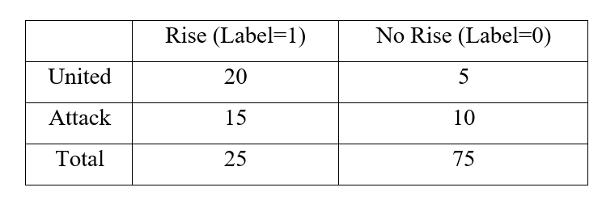

First, the **prior probability** of the two labels can be calculated as:

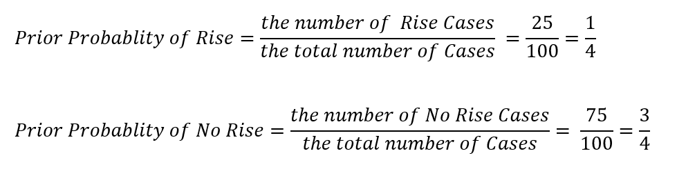

Then, the **likelihood** of the two labels can be calculated for each keyword:

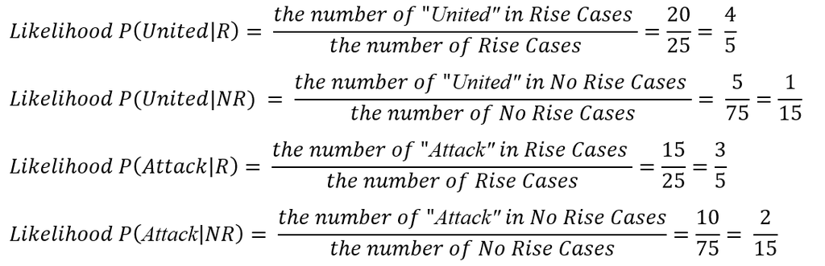

Finally, the **marginal likelihood** of the two keywords can be calculated as the formulas below.

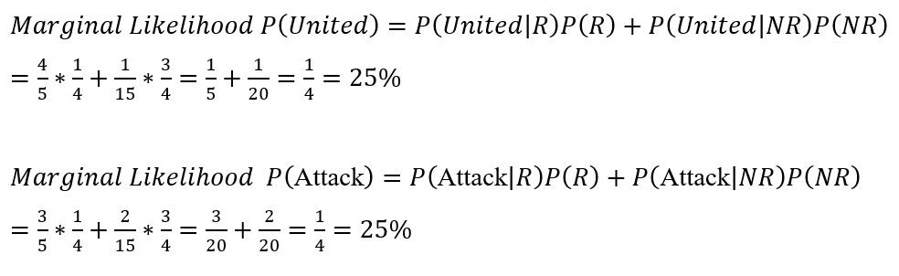

Appling Bayes' Theorem, we can obtain the probability of Rise and No Rise given the observed keywords.

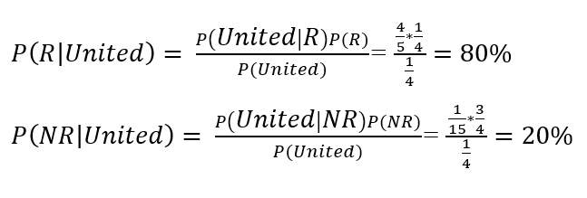

Since 80% is larger than 20%, we would associate “United” with rising stock price with a probability of 80%.

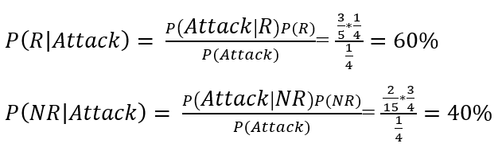

As 60% is larger than 40%, we would associate “Attack” with rising stock price with a probability of 60%. One thing worth pointing out here is that the estimated probability could be highly biased if the assumption of independent features does not hold true, but that will not be a big problem for us since we focus more on the ranking of probabilities and the binary predictions.

### (b) Techniques for Text Analysis

In data preprocessing and model refinement, several different techniques will be applied to text data analysis, including text cleaning, word cloud, stop words selection, sub-words splitting and so forth. However, such techniques are not the key for this project and will not be discussed in detail.

## 02.Pre-processing & Predictive Modelling

### (a) Data Preprocessing Pipeline

Our data preprocessing pipeline is described as the following diagram, which can be divided into five main parts.

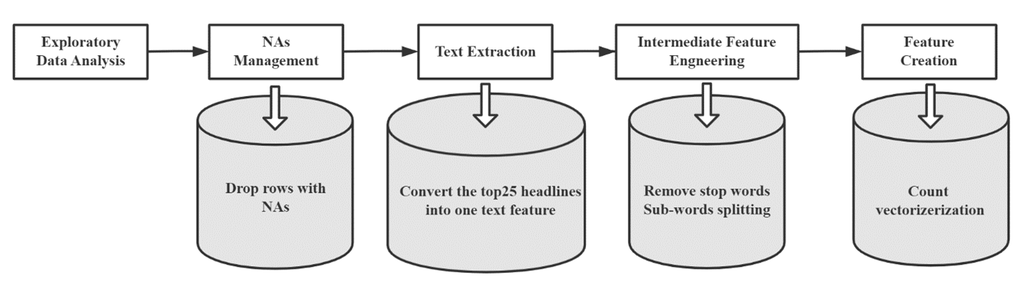

```python
# import packages
import pandas as pd
import numpy as np
import matplotlib.pyplot as plt
import seaborn as sns
from wordcloud import WordCloud, STOPWORDS
import nltk
from nltk.stem import PorterStemmer, WordNetLemmatizer
from nltk.corpus import stopwords
from nltk.tokenize import word_tokenize, sent_tokenize
import gensim
from gensim.utils import simple_preprocess
from gensim.parsing.preprocessing import STOPWORDS
from sklearn.metrics import classification_report, confusion_matrix
from confusion_matrix import func_calConfusionMatrix
import warnings
warnings.filterwarnings('ignore')
```

```python
# load the data
df = pd.read_csv('Stock_data.csv', encoding = 'latin-1')
df.head(3)
```

|  | Date | Label | Top1 | Top2 | Top3 | Top4 | Top5 | Top6 | Top7 | Top8 | ... | Top16 | Top17 | Top18 | Top19 | Top20 | Top21 | Top22 | Top23 | Top24 | Top25 |
| --- | --- | --- | --- | --- | --- | --- | --- | --- | --- | --- | --- | --- | --- | --- | --- | --- | --- | --- | --- | --- | --- |
| 0 | 2000-01-03 | 0 | A 'hindrance to operations': extracts from the... | Scorecard | Hughes' instant hit buoys Blues | Jack gets his skates on at ice-cold Alex | Chaos as Maracana builds up for United | Depleted Leicester prevail as Elliott spoils E... | Hungry Spurs sense rich pickings | Gunners so wide of an easy target | ... | Flintoff injury piles on woe for England | Hunters threaten Jospin with new battle of the... | Kohl's successor drawn into scandal | The difference between men and women | Sara Denver, nurse turned solicitor | Diana's landmine crusade put Tories in a panic | Yeltsin's resignation caught opposition flat-f... | Russian roulette | Sold out | Recovering a title |
| 1 | 2000-01-04 | 0 | Scorecard | The best lake scene | Leader: German sleaze inquiry | Cheerio, boyo | The main recommendations | Has Cubie killed fees? | Has Cubie killed fees? | Has Cubie killed fees? | ... | On the critical list | The timing of their lives | Dear doctor | Irish court halts IRA man's extradition to Nor... | Burundi peace initiative fades after rebels re... | PE points the way forward to the ECB | Campaigners keep up pressure on Nazi war crime... | Jane Ratcliffe | Yet more things you wouldn't know without the ... | Millennium bug fails to bite |
| 2 | 2000-01-05 | 0 | Coventry caught on counter by Flo | United's rivals on the road to Rio | Thatcher issues defence before trial by video | Police help Smith lay down the law at Everton | Tale of Trautmann bears two more retellings | England on the rack | Pakistan retaliate with call for video of Walsh | Cullinan continues his Cape monopoly | ... | South Melbourne (Australia) | Necaxa (Mexico) | Real Madrid (Spain) | Raja Casablanca (Morocco) | Corinthians (Brazil) | Tony's pet project | Al Nassr (Saudi Arabia) | Ideal Holmes show | Pinochet leaves hospital after tests | Useful links |

3 rows × 27 columns

#### • Exploratory Data Aanlysis Automation

```python
import pandas_profiling as pp
report = pp.ProfileReport(df)
report
```

[interactive chart not shown]

#### • NAs Management

NAs appear only in a few rows, so we here simply drop such rows.

```python
# check NAs
df.info()
```

```
<class 'pandas.core.frame.DataFrame'>
RangeIndex: 4101 entries, 0 to 4100
Data columns (total 27 columns):
 #   Column  Non-Null Count  Dtype
---  ------  --------------  -----
 0   Date    4101 non-null   object
 1   Label   4101 non-null   int64
 2   Top1    4101 non-null   object
 3   Top2    4101 non-null   object
 4   Top3    4101 non-null   object
 5   Top4    4101 non-null   object
 6   Top5    4101 non-null   object
 7   Top6    4101 non-null   object
 8   Top7    4101 non-null   object
 9   Top8    4101 non-null   object
```

[output cut: 19 more lines]

```python
# drop rows with NAs
df = df.dropna(axis = 0)
```

```python
# drop date
df = df.drop("Date", axis =1)
```

#### • Check Labels Imbalance

We found that the distribution of labels in total 4098 samples does not display the problem of imbalanced class.

```python
# check label
df['Label'].value_counts()
```

```
1    2163
0    1935
Name: Label, dtype: int64
```

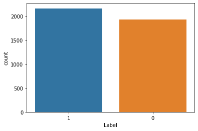

```python
# Plot the counts of go-up cases vs not go-up cases
sns.countplot(df['Label'], order=[1,0],label='Count Plot')
```

#### • Text Extraction

We merge all 25 top headlines into one column to prepare for the next step.

```python
#  convert the top25 headlines into one single record
df['headline_text'] = df[df.columns[1:]].apply(lambda x: ','.join(x.dropna()),axis=1)
```

```python
df['headline_text'] [0]
```

```
"A 'hindrance to operations': extracts from the leaked reports,Scorecard,Hughes' instant hit buoys Blues,Jack gets his skates on at ice-cold Alex,Chaos as Maracana builds up for United,Depleted Leicester prevail as Elliott spoils Everton's party,Hungry Spurs sense rich pickings,Gunners so wide of an…
```

```python
# drop top25 separated headlines
df_clean = df.drop(df.columns[1:26], axis = 1)
```

```python
df_clean['Label'] = df_clean['Label'].astype('category')
df_clean.info()
```

```
<class 'pandas.core.frame.DataFrame'>
Int64Index: 4098 entries, 0 to 4100
Data columns (total 2 columns):
 #   Column         Non-Null Count  Dtype
---  ------         --------------  -----
 0   Label          4098 non-null   category
 1   headline_text  4098 non-null   object
dtypes: category(1), object(1)
memory usage: 197.2+ KB
```

#### • Intermediate Feature Engineering

To reduce the impact of noises, here we try to eliminate useless words from our dataset, we defined that words with and less than 2 characters, and those frequently appear with low values (stop words).

```python
# Get stopwords from nltk and customize them
from nltk.corpus import stopwords

stop_words = stopwords.words('english')
#stop_words.extend(['from','subject','use']) # add some useless words
```

```python
# text preprocess: remove stop words and words with 2 or less characters
def text_preprocess(text):
    result = []
    for token in gensim.utils.simple_preprocess(text) : # for every word in the text, convert them into a list of lowercase tokens and also ignoring tokens that are too short or too long
        if token not in gensim.parsing.preprocessing.STOPWORDS and len(token) > 2 and token not in stop_words:
            result.append(token)

    return ' '.join(result)
```

```python
# Cleaned text
df_clean['cleaned_text'] = df_clean['headline_text'].apply(text_preprocess)
```

```python
df_clean
```

|  | Label | headline_text | cleaned_text |
| --- | --- | --- | --- |
| 0 | 0 | A 'hindrance to operations': extracts from the... | hindrance operations extracts leaked reports s... |
| 1 | 0 | Scorecard,The best lake scene,Leader: German s... | scorecard best lake scene leader german sleaze... |
| 2 | 0 | Coventry caught on counter by Flo,United's riv... | coventry caught counter flo united rivals road... |
| 3 | 1 | Pilgrim knows how to progress,Thatcher facing ... | pilgrim knows progress thatcher facing ban mci... |
| 4 | 1 | Hitches and Horlocks,Beckham off but United su... | hitches horlocks beckham united survive breast... |
| ... | ... | ... | ... |
| 4096 | 0 | Barclays and RBS shares suspended from trading... | barclays rbs shares suspended trading tanking ... |
| 4097 | 1 | 2,500 Scientists To Australia: If You Want To ... | scientists australia want save great barrier r... |
| 4098 | 1 | Explosion At Airport In Istanbul,Yemeni former... | explosion airport istanbul yemeni president te... |
| 4099 | 1 | Jamaica proposes marijuana dispensers for tour... | jamaica proposes marijuana dispensers tourists... |
| 4100 | 1 | A 117-year-old woman in Mexico City finally re... | year old woman mexico city finally received bi... |

4098 rows × 3 columns

```python
print(df_clean['headline_text'][0])
```

```
A 'hindrance to operations': extracts from the leaked reports,Scorecard,Hughes' instant hit buoys Blues,Jack gets his skates on at ice-cold Alex,Chaos as Maracana builds up for United,Depleted Leicester prevail as Elliott spoils Everton's party,Hungry Spurs sense rich pickings,Gunners so wide of an …
```

```python
print(df_clean['cleaned_text'][0])
```

```
hindrance operations extracts leaked reports scorecard hughes instant hit buoys blues jack gets skates ice cold alex chaos maracana builds united depleted leicester prevail elliott spoils everton party hungry spurs sense rich pickings gunners wide easy target derby raise glass strupar debut double s…
```

#### • Word Cloud

By comparing the word cloud for both classes, we can see the dominant words are somewhat different.

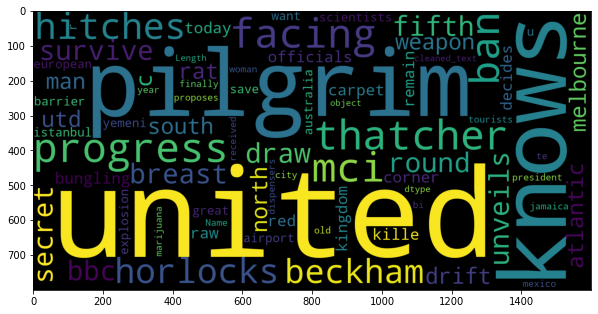

```python
# plot the word cloud for Rise cases (Label=1)
plt.figure(figsize = (10,10))
wc = WordCloud(max_words = 2000, width = 1600, height = 800, stopwords = stop_words)
wc.generate(str(df_clean['cleaned_text'][df_clean['Label']==1]))

plt.imshow(wc)
```

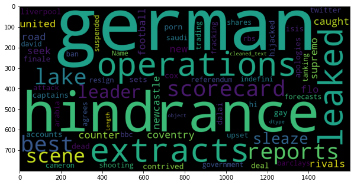

```python
# plot the word cloud for No Rise cases (Label=0)
plt.figure(figsize = (10,10))
wc = WordCloud(max_words = 2000, width = 1600, height = 800, stopwords = stop_words)
wc.generate(str(df_clean['cleaned_text'][df_clean['Label']==0]))

plt.imshow(wc)
```

#### • Feature Creation

Now, we can use the CountVectorizer to create our features (matrix) for ML models on the basis of cleaned text.

```python
# Applying CountVectorier to the cleaned text
from sklearn.feature_extraction.text import CountVectorizer

vectorizer = CountVectorizer()
v = vectorizer.fit_transform(df_clean['cleaned_text'])
```

```python
# a glimpse of text feature names
print(vectorizer.get_feature_names()[1:100])
```

```
['aaaw', 'aab', 'aabo', 'aadmi', 'aafia', 'aah', 'aali', 'aam', 'aamer', 'aamir', 'aap', 'aaron', 'aaronovitch', 'aarp', 'ababa', 'aback', 'abadan', 'abadi', 'abajo', 'aban', 'abandon', 'abandoned', 'abandoning', 'abandonment', 'abandons', 'abate', 'abating', 'abattoir', 'abattoirs', 'abay', 'abaya'…
```

```python
print(v.toarray())
```

```
[[0 0 0 ... 0 0 0]
 [0 0 0 ... 0 0 0]
 [0 0 0 ... 0 0 0]
 ...
 [0 0 0 ... 0 0 0]
 [0 0 0 ... 0 0 0]
 [0 0 0 ... 0 0 0]]
```

```python
# create predictors
X = v
X.shape
```

```
(4098, 45982)
```

```python
# create target
Y = df_clean['Label']
Y.shape
```

```
(4098,)
```

```python
# sample splitting (80% training set, 20% testing set)
from sklearn.model_selection import train_test_split

X_train, X_test, Y_train, Y_test = train_test_split(X, Y, test_size=0.2, random_state = 1 )
```

### (b) Predictive Modelling: The Baseline Model

Based on the above experimental settings, here we will train our baseline native bayes classifer and test its out-of-sample performance. The accuracy and precision rate are standards to judge whether a model is good enough. We use a confusion matrix to visualize such values.

```python
from sklearn.naive_bayes import MultinomialNB

model = MultinomialNB()
model.fit(X_train, Y_train)
```

```
MultinomialNB()
```

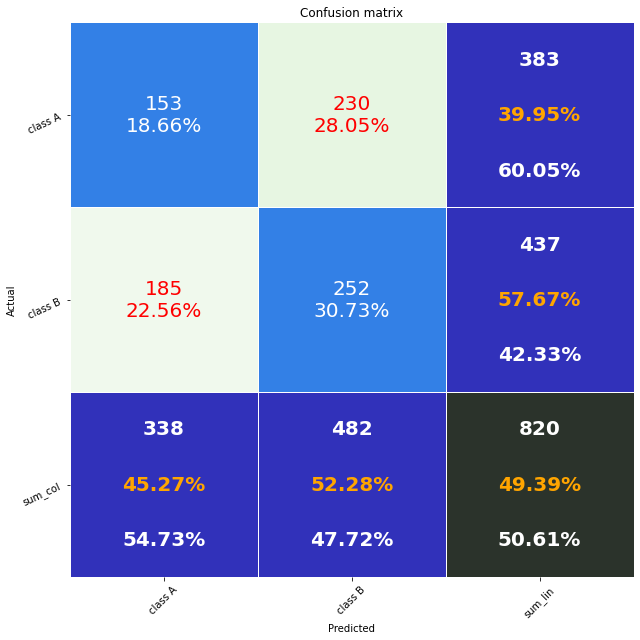

```python
# Predicting the Test set results
Y_pred = model.predict(X_test)
Y_real = Y_test

func_calConfusionMatrix(Y_pred,Y_real)
```

```python
# classification report
print(classification_report(Y_test, Y_pred))
```

```
              precision    recall  f1-score   support

           0       0.45      0.40      0.42       383
           1       0.52      0.58      0.55       437

    accuracy                           0.49       820
   macro avg       0.49      0.49      0.49       820
weighted avg       0.49      0.49      0.49       820
```

From the testing results, we can see the total accuracy of our baseline model is only 49.39%, which is worse than a random guess. The precision rate for No Rise is 0.45, while for Rise scenario is 0.52.

So, the information of news headlines does not help us a lot to better understand the future variation of stock price. However, another possible reason is that noises in our dataset distort the prediction.

### (c) Predictive Modelling: The Refined Model

Since the performace of the baseline model is not good, here we try to further engineer our features and try to improve its performance. The method we use is sub-words splitting.The algorithm below helps to divide words into sub-words with 2 or 3 characteristics automatically.

```python
# taken from https://arxiv.org/abs/1508.07909
import pickle as pkl

def split_into_subwords(text):
    merges = pkl.load(open('E:/UCLA Econ Course/412 Fundamentals of Big Data/HW01/merge_ordered.pkl', 'rb')) # an encapsulated model
    subwords = []
    for word in text.split():
        for subword in merges:
            subword_count = word.count(subword)
            if subword_count > 0:
                word = word.replace(subword, ' ')
                subwords.extend([subword]*subword_count)
    return ' '.join(subwords)
```

```python
subwords = []
for i in df_clean["cleaned_text"]:
    subwords.append(split_into_subwords(i))
```

```python
df_clean['subwords'] = pd.DataFrame(subwords)
```

```python
df_clean.head()
```

|  | Label | headline_text | cleaned_text | subwords |
| --- | --- | --- | --- | --- |
| 0 | 0 | A 'hindrance to operations': extracts from the... | hindrance operations extracts leaked reports s... | in an ce er at on op ra ts ex ed le ak re or t... |
| 1 | 0 | Scorecard,The best lake scene,Leader: German s... | scorecard best lake scene leader german sleaze... | ar re co es la ke en er le ad an er le in ir e... |
| 2 | 0 | Coventry caught on counter by Flo,United's riv... | coventry caught counter flo united rivals road... | en co gh er un co lo ed it un al ri ro ad ri e... |
| 3 | 1 | Pilgrim knows how to progress,Thatcher facing ... | pilgrim knows progress thatcher facing ban mci... | il ri es ro er at ch th in ac an il ro al is i... |
| 4 | 1 | Hitches and Horlocks,Beckham off but United su... | hitches horlocks beckham united survive breast... | es it ch or lo am ed it un ur iv re st an er i... |

```python
# get the features matrix
vectorizer = CountVectorizer()
v = vectorizer.fit_transform(subwords)
```

```python
X_subwords = v
X_subwords.shape
```

```
(4098, 73)
```

```python
X_subwords_train, X_subwords_test, Y_train, Y_test = train_test_split(X_subwords, Y, test_size=0.2, random_state = 1 )

model_02 = MultinomialNB()
model_02.fit(X_subwords_train, Y_train)
```

```
MultinomialNB()
```

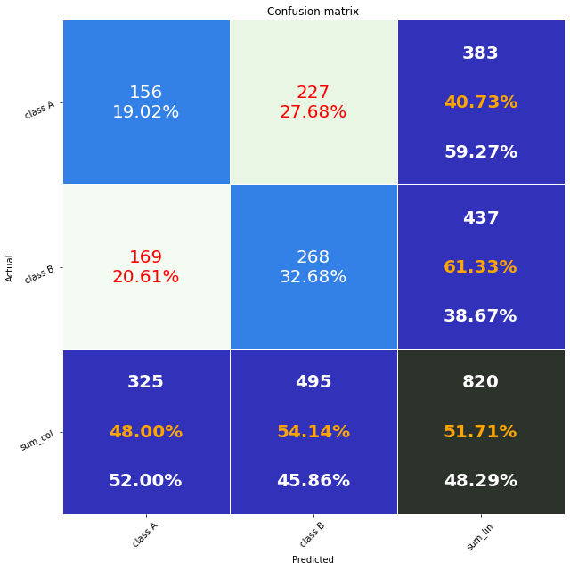

```python
# Predicting the Test set results
Y_pred = model_02.predict(X_subwords_test)
Y_real = Y_test

func_calConfusionMatrix(Y_pred,Y_real)
```

```python
# classification report
print(classification_report(Y_test, Y_pred))
```

```
              precision    recall  f1-score   support

           0       0.48      0.41      0.44       383
           1       0.54      0.61      0.58       437

    accuracy                           0.52       820
   macro avg       0.51      0.51      0.51       820
weighted avg       0.51      0.52      0.51       820
```

From the testing results of our new model, we can tell the total accuracy increased to 51.71%, which is better than a random guess. The precision rate for No Rise increased to 0.48, and the precision rate for Rise scenario increased 0.54. So, we can see the method of sub-word splitting improved the model performance. The information of news headlines have the potential to aid the stock price prediction.

## 03.Robustness Test

To futher test the robustness of our models, we will implement cross-validation for each model and plot their learning curves. In this part, we increase the size of training set step by step and plot the training accuracy and respective 10-fold cross-validation accuracy for each model.

```python
from sklearn.model_selection import learning_curve
from sklearn.model_selection import ShuffleSplit

# learning curve
def plot_learning_curve(estimator, title, X, y, ylim=None, cv=None,
                        n_jobs=1, train_sizes=np.linspace(.1, 1.0, 5)):
    plt.figure()
    plt.title(title)
    if ylim is not None:
        plt.ylim(*ylim)
    # x
    plt.xlabel("Training examples")
    # y
    plt.ylabel("Score")
    train_sizes, train_scores, test_scores = learning_curve(
        estimator, X, y, cv=cv, n_jobs=n_jobs, train_sizes=train_sizes)
    train_scores_mean = np.mean(train_scores, axis=1)
    test_scores_mean = np.mean(test_scores, axis=1)
    plt.grid()
    plt.plot(train_sizes, train_scores_mean, 'o-', color="r",
             label="Training score")
    plt.plot(train_sizes, test_scores_mean, 'o-', color="g",
             label="Cross-validation score")

    plt.legend(loc="lower right")
    return plt
```

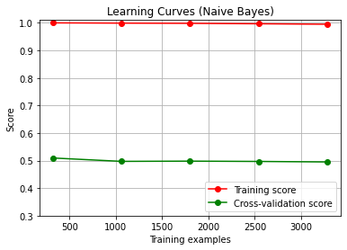

```python
# learning curve for the baseline model
title = "Learning Curves (Naive Bayes)"
cv = ShuffleSplit(n_splits=10, test_size=0.2, random_state=1)
estimator = MultinomialNB()
plot_learning_curve(estimator, title, X, Y, ylim=(0.3, 1.01), cv=cv, n_jobs=4)

plt.show()
```

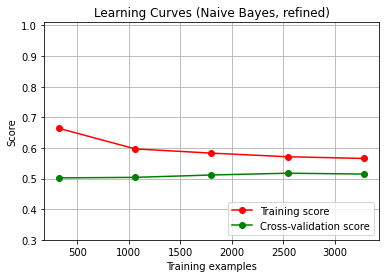

```python
# learning curve for the refined model
title = "Learning Curves (Naive Bayes, refined)"
cv = ShuffleSplit(n_splits=10, test_size=0.2, random_state=1)
estimator = MultinomialNB()
plot_learning_curve(estimator, title, X_subwords, Y, ylim=(0.3, 1.01), cv=cv, n_jobs=4)

plt.show()
```

We can see for the baseline model, the training score and cv score are very consistant over different sample size. The training score is close to 1 but the test performance is very similar to a random guess. A significant display of over-fitting.

For the refined model, we can tell the training score and cv score changes as the sample size goes up. Also, such two metrics become more stable as the sample size is over 2500. There still exist the problem of over-fitting, but we can conclude that sub-words splitting is an effective way to improve our prediction and justify the value of news headlines in the prediction of stock price.

## 04.Economic Insights

By ploting the dominant words for each class, we can tell the high-frequency words are different between these two classes. For Rise cases, the most popular words are united, pilgrim, hitches and draw-round. For No Rise cases, those words change to german, hindrance, and operations. However, we can not directly make use of such difference by simply applying the Naive Bayes algorithm. The testing performace was not better than a random guess.

On the basis of some techniques of NLP, we successfully refined our baseline model and found that the testing accuracy of our new model was constantly higher than 50% given a relatively larger dataset. This result is inspiring to any applictions which are trying to include text data for a deeper understanding of stock price.

## 05.Summary and Future Improvement

In this project, we developed a whole pipeline to build an ML application of Naive Bayes, which display effectiveness in the prediction of stock price. Through EDA, NAs management and a series of processes of feature enginerring, we prepared our news text data and built two Naive Bayes classifiers. We also justified the robustness of our model by cross-validation.

Based on this application, we hope more trials and explorations will happen in this field for basic research on stocks or even more sophisticated predictive systems for solid investment suggestions. We believe there are at least two aspects where improvement is promising in the future works.

First, mitigating the problem of over-fitting. It is hard to provide satisfying prediction based on news data itself, datasets that contain richer information should be involved for a better prediction. Second, analyzing the market sentiment. Although the data could be limited, more advanced techniques make it posible to unleash valuable signals from the data. Sentiment analysis provides powerful techniques for us to obtain insights from text data. New sentiment predictors would be able to construct and potentially add value to our prediction.

## 06.Reference

1. https://www.kaggle.com/aaron7sun/stocknews
2. Dr. Randall R. Rojas, ECON 412 Sequential Bayesian Learning Lecture 1: Naïve Bayes, Page 34-51
3. https://www.coursera.org/projects/resume-selector-using-naive-bayes
4. Sennrich, Rico, Barry Haddow, and Alexandra Birch. "Neural machine translation of rare words with subword units." arXiv preprint arXiv:1508.07909 (2015).
5. https://www.coursera.org/projects/language-classification